# Homework #5 - Answer Key

Mark Scheuerell

# Background

Here are the answers for the homework problems from the sixth week of class on the Dynamic Linear Models (DLMs) material. Begin by getting the data

```r
## get S-R data; cols are:
## 1: brood yr (brood.yr)
## 2: number of spawners (Sp)
## 3: number of recruits (Rec)
## 4: PDO during first summer at sea (PDO.t2)
## 5: PDO during first winter at sea (PDO.t3)
load("KvichakSockeye.RData")
## head of data file
head(SRdata)
```

```
##   brood.yr   Sp   Rec PDO.t2 PDO.t3
## 1     1952 5970 17310  -0.61  -0.61
## 2     1953  320   520  -1.48  -2.66
## 3     1954  240   750  -2.05  -1.26
## 4     1955  250  1280   0.01   0.11
## 5     1956 9443 39036   0.86   0.37
## 6     1957 2843  4091  -0.25   0.29
```

# Question 1

Begin by fitting a reduced form of Equation 15 that includes only a time-varying level ($\alpha_t$) and observation error ($v_t$). That is,

$$\begin{equation}
\begin{aligned}
\text{log}(R_t) &= \alpha_t + \text{log}(S_t) + v_t \\
\text{log}(R_t/S_t) &= \alpha_t + v_t
\end{aligned}
\end{equation}$$

This model assumes no density-dependent survival in that the number of recruits is an ascending function of spawners. Plot the ts of $\alpha_t$ and note the AICc for this model. Also plot appropriate model diagnostics.

## Answer

The stock-recruit model here is a random walk observed with error, which we have seen a lot in class. To see the equivalency, instead write the observation model as

$$\begin{equation}
y_t = x_t + v_t
\end{equation}$$

where $y_t = \text{log}(R_t/S_t)$ and $x_t = \alpha_t$. The process model is then

$$\begin{equation}
x_t = x_{t-1} + w_t
\end{equation}$$

The first thing we need is to compute the response variable $y_t = \text{log}(R_t/S_t)$.

```r
## Time series of ln(R/S)
lnRS <- log(SRdata$Rec/SRdata$Sp)
dat <- matrix(lnRS, nrow=1)
## number of years of data--we'll need this later
TT <- length(lnRS)
```

Now we can set up the DLM as a level-only model (i.e., a random walk with observation error) and fit it with MARSS.

```r
library(MARSS)
## MARSS model defn
## for process eqn
BB <- matrix(1)
UU <- matrix(0)
QQ <- matrix("q")
## for observation eqn
ZZ <- matrix(1)
AA <- matrix(0)
RR <- matrix("r")
## only need starting values for regr parameters
inits_list <- list(x0=matrix(1))
## list of model matrices & vectors
mod_list <- list(B=BB, U=UU, Q=QQ, Z=ZZ, A=AA, R=RR, tinitx=0)
## fit DLM
Q1 <- MARSS(dat, inits=inits_list, model=mod_list)
```

```
## Success! abstol and log-log tests passed at 22 iterations.
## Alert: conv.test.slope.tol is 0.5.
## Test with smaller values (<0.1) to ensure convergence.
##
## MARSS fit is
## Estimation method: kem
## Convergence test: conv.test.slope.tol = 0.5, abstol = 0.001
## Estimation converged in 22 iterations.
## Log-likelihood: -48.67502
## AIC: 103.35   AICc: 104.0559
##
##       Estimate
## R.r      0.271
## Q.q      0.318
## x0.x0    0.953
##
## Standard errors have not been calculated.
## Use MARSSparamCIs to compute CIs and bias estimates.
```

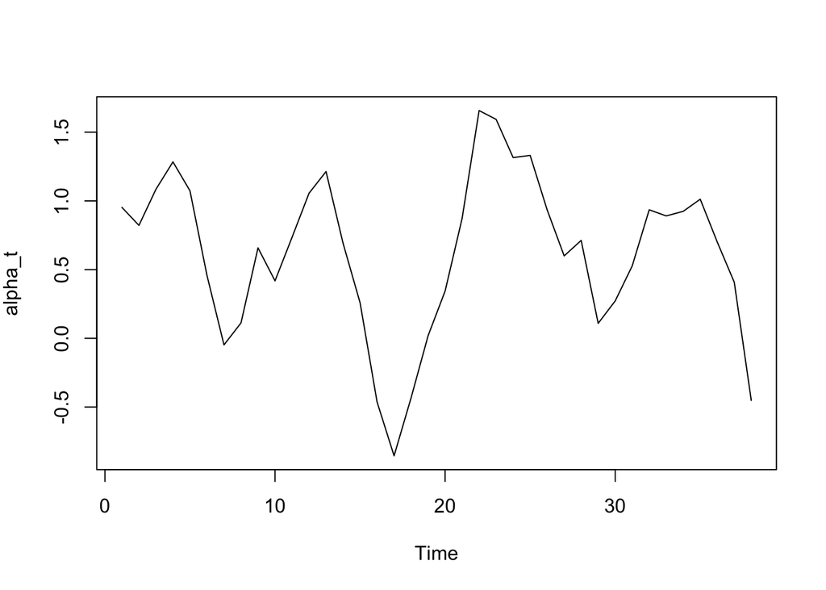

```r
## plot the time-varying level
plot.ts(t(Q1$states), ylab=expression(alpha_t))
```

```r
## get AICc
Q1$AICc
```

```
## [1] 104.0559
```

And finally examine some diagnostic plots:

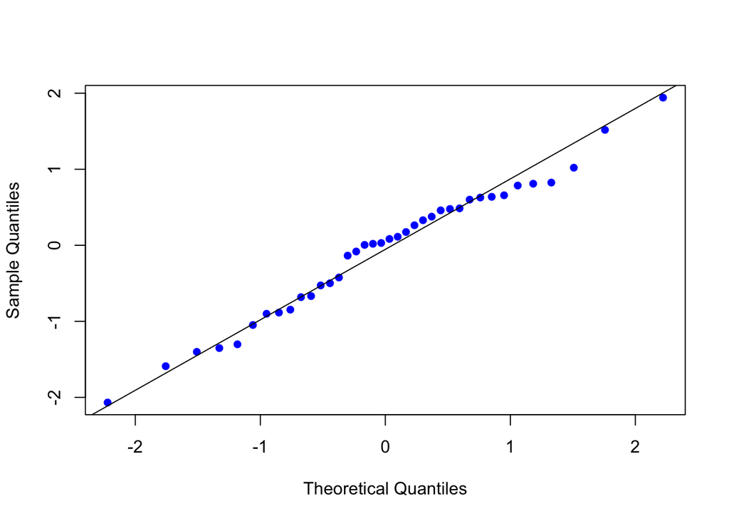

```r
## get list of Kalman filter output
kf_out <- MARSS::MARSSkfss(Q1)
## forecast errors
innov <- kf_out$Innov
## Q-Q plot of forecast errors
qqnorm(t(innov), main="", pch=16, col="blue")
## add y=x line for easier interpretation
qqline(t(innov))
```

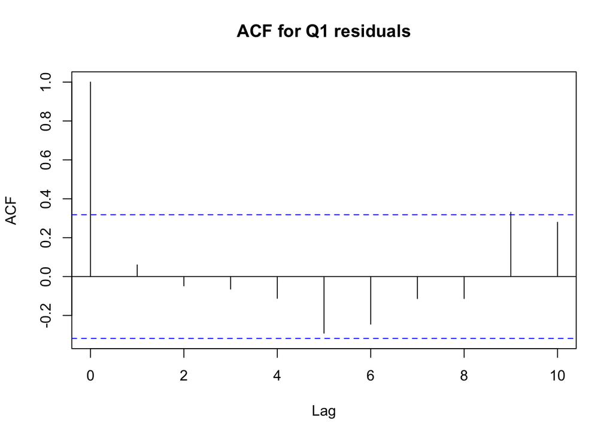

```r
## plot ACF of innovations
acf(t(innov), lag.max=10, main="ACF for Q1 residuals")
```

The residuals seem to be reasonably well behaved in that there appear normal with no significant autocorrelation.

# Question 2

Fit the full model specified by Equation 15. For this model, obtain the time series of $\alpha_t$, which is an estimate of the stock productivity in the absence of density-dependent effects. How do these estimates of productivity compare to those from the previous question? Plot the ts of $\alpha_t$ and note the AICc for this model. Also plot appropriate model diagnostics. ($Hint$: If you don’t want a parameter to vary with time, what does that say about its process variance?)

## Answer

Now we need to fit a DLM with a time-varying level (intercept), but time-invariant slope. Begin by obtaining the time series of spawners to use as the covariate.

```r
Sp <- matrix(SRdata$Sp, nrow=1)/10000
```

Set up the MARSS model structure so $\alpha$ varies with time, but not $\beta$, which means $q=0$ for $\beta$. This means that $\mathbf{Q}$ should be

$$\begin{equation}
\mathbf{Q} = \begin{bmatrix}
q_\alpha&0 \\
0&0
\end{bmatrix}
\end{equation}$$

```r
## number of regr coefs
m <- 2
## MARSS model defn
## for process eqn
B <- diag(m)                   ## 2x2; Identity
U <- matrix(0,nrow=m,ncol=1)   ## 2x1; both elements = 0
Q <- matrix(list(0),m,m)       ## 2x2; all 0 for now
Q[1,1] <- "q_alpha"              ## 2x2; diag = (q1,q2)
## for observation eqn
Z <- array(NA, c(1,m,TT))   ## NxMxT; empty for now
Z[1,1,] <- rep(1,TT)        ## Nx1; 1's for intercept
Z[1,2,] <- Sp               ## Nx1; regr variable
A <- matrix(0)              ## 1x1; scalar = 0
R <- matrix("r")            ## 1x1; scalar = r
## only need starting values for regr parameters
inits_list <- list(x0=matrix(c(0, 0), nrow=m))
## list of model matrices & vectors
mod_list <- list(B=B, U=U, Q=Q, Z=Z, A=A, R=R)
## list of control params
con_list <- list(maxit=2000)
## fit DLM
Q2 <- MARSS(dat, inits=inits_list, model=mod_list, control=con_list)
```

```
## Success! abstol and log-log tests passed at 21 iterations.
## Alert: conv.test.slope.tol is 0.5.
## Test with smaller values (<0.1) to ensure convergence.
##
## MARSS fit is
## Estimation method: kem
## Convergence test: conv.test.slope.tol = 0.5, abstol = 0.001
## Estimation converged in 21 iterations.
## Log-likelihood: -48.5829
## AIC: 105.1658   AICc: 106.3779
##
##           Estimate
## R.r         0.2682
## Q.q_alpha   0.3191
## x0.X1       0.9855
## x0.X2      -0.0807
##
## Standard errors have not been calculated.
## Use MARSSparamCIs to compute CIs and bias estimates.
```

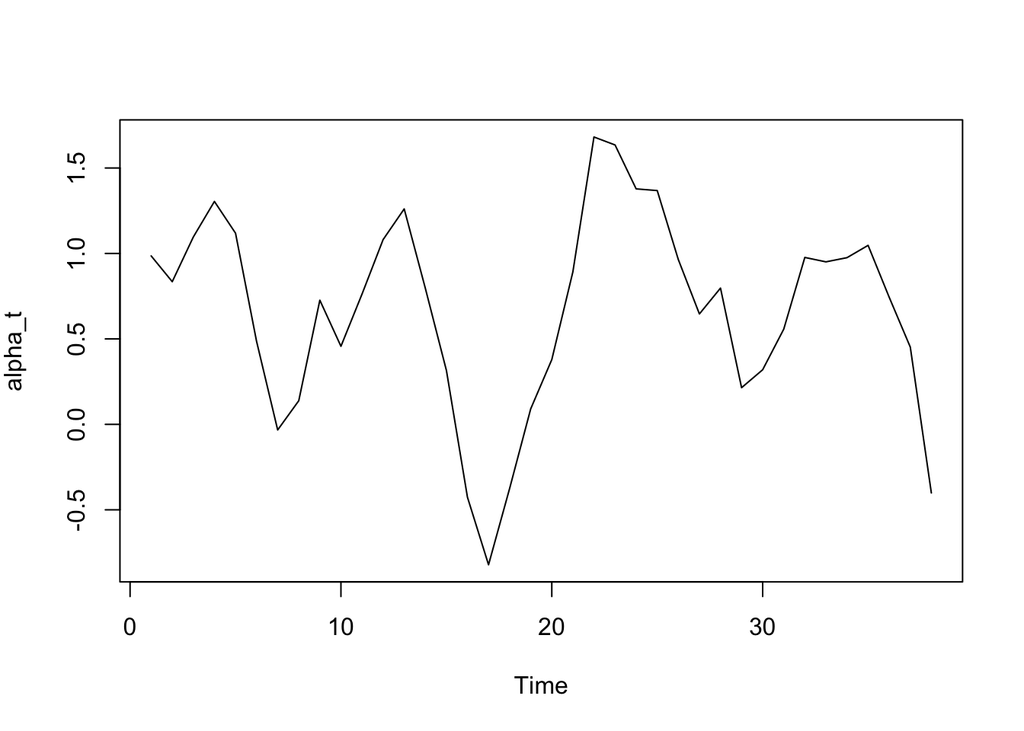

```r
## plot the time-varying level
plot.ts(Q2$states[1,], ylab=expression(alpha_t))
```

Now let’s check the AICc value.

```r
## get AIC
Q2$AICc
```

```
## [1] 106.3779
```

Let’s check out some diagnostic plots for the model in Q2. First we get the model innovations from our fitted `MARSS` object.

```r
## get list of Kalman filter output
kf_out <- MARSS::MARSSkfss(Q2)
## forecast errors
innov <- kf_out$Innov
```

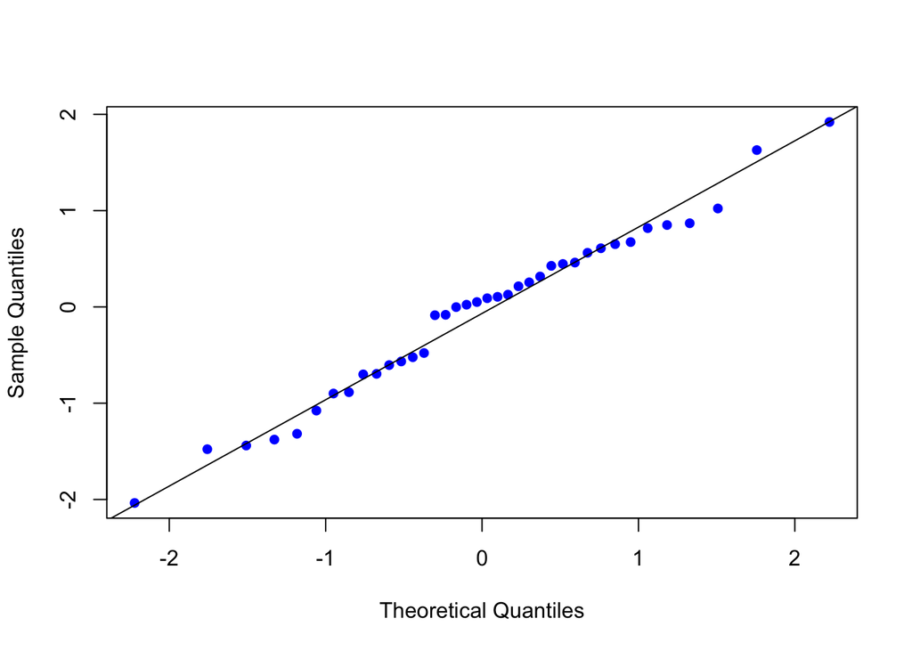

```r
## Q-Q plot of forecast errors
qqnorm(t(innov), main="", pch=16, col="blue")
## add y=x line for easier interpretation
qqline(t(innov))
```

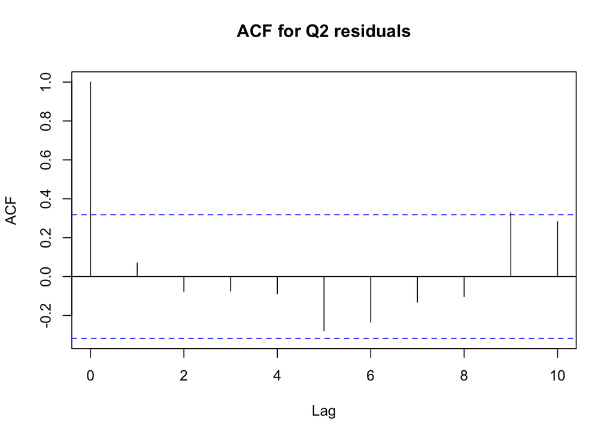

```r
## plot ACF of innovations
acf(t(innov), lag.max=10, main="ACF for Q2 residuals")
```

# Question 3

Fit the model specified by Equation 16 with the summer PDO index as the covariate (`PDO.t2`). What is the mean level of productivity? Plot the ts of $\delta_t$ and note the AICc for this model. Also plot appropriate model diagnostics.

## Answer

Now we need to fit a DLM so $\alpha$ and $\beta$ are time-invariant, but $\delta$ varies by year. This means that $\mathbf{Q}$ should be

$$\begin{equation}
\mathbf{Q} = \begin{bmatrix}
0&0&0 \\
0&0&0 \\
0&0&q_\delta \end{bmatrix}
\end{equation}$$

```r
## number of regr coefs
m <- 3
## MARSS model defn
## for process eqn
B <- diag(m) ## 2x2; Identity
U <- matrix(0,nrow=m,ncol=1)
Q <- matrix(list(0),m,m)
## place delta last--it's the only one to time-vary
Q[3,3]=("q_delta")
## for observation eqn
Z <- array(NA, c(1,m,TT)) ## NxMxT; empty for now
Z[1,1,] <- rep(1,TT)  ## 1's for intercept
Z[1,2,] <- SRdata[,2] ## Sp regr variable
Z[1,3,] <- SRdata[,4] ## summer PDO regr variable
A <- matrix(0) ## 1x1; scalar = 0
R <- matrix("r") ## 1x1; scalar = r
## only need starting values for regr parameters
inits_list <- list(x0=matrix(c(0,0,0), nrow=m))
## list of model matrices & vectors
mod_list <- list(B=B, U=U, Q=Q, Z=Z, A=A, R=R)
## list of control params
con_list <- list(maxit=2000, allow.degen=TRUE)
## fit DLM
Q3 <- MARSS(dat, inits=inits_list, model=mod_list, control=con_list)
```

```
## Success! abstol and log-log tests passed at 807 iterations.
## Alert: conv.test.slope.tol is 0.5.
## Test with smaller values (<0.1) to ensure convergence.
## Alert: Numerical warnings were generated. Print the $errors element of output to see the warnings.
##
## MARSS fit is
## Estimation method: kem
## Convergence test: conv.test.slope.tol = 0.5, abstol = 0.001
## Estimation converged in 807 iterations.
## Log-likelihood: -34.30589
## AIC: 78.61177   AICc: 80.48677
##
##            Estimate
## R.r        7.20e-01
## Q.q_delta  0.00e+00
## x0.X1      7.20e-01
## x0.X2     -1.72e-05
## x0.X3      4.52e-02
##
## Standard errors have not been calculated.
## Use MARSSparamCIs to compute CIs and bias estimates.
##
## MARSSkem warnings. Type MARSSinfo() for help.
##  MARSSkem: The soln became unstable and logLik DROPPED.
##
## Use control$trace=1 to generate a more detailed error report.
```

```r
## mean productivity
mean(Q3$states[1,])
```

```
## [1] 0.7197999
```

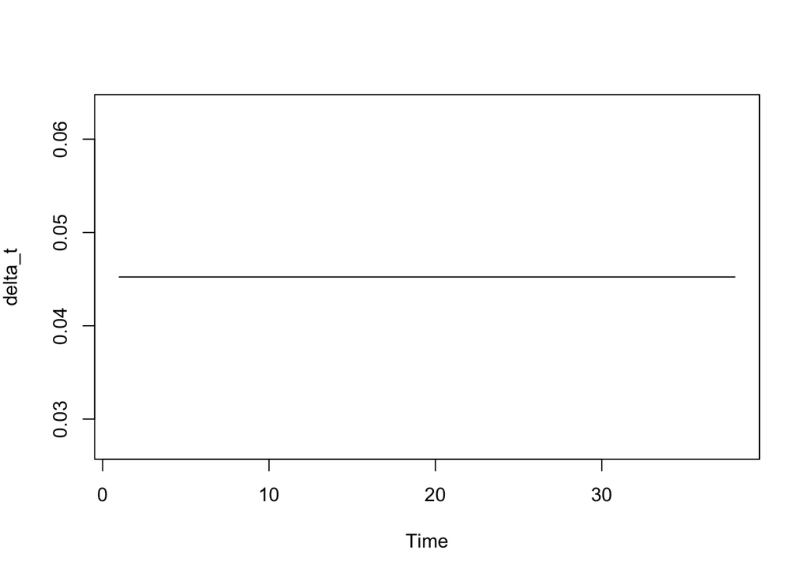

```r
## plot the time-varying effect of PDO
plot.ts(Q3$states[3,], ylab=expression(delta_t))
```

```r
## get AIC
Q3$AICc
```

```
## [1] 80.48677
```

Here are some diagnostic plots:

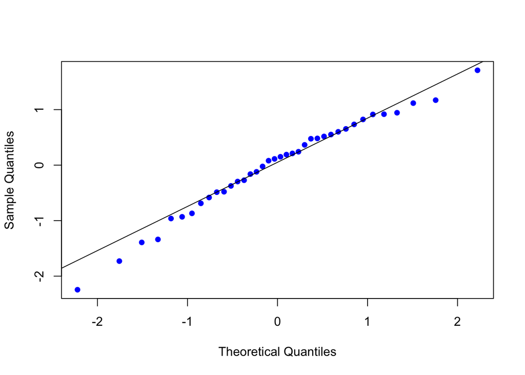

```r
## get list of Kalman filter output
kf_out <- MARSS::MARSSkfss(Q3)
## forecast errors
innov <- kf_out$Innov
## Q-Q plot of forecast errors
qqnorm(t(innov), main="", pch=16, col="blue")
## add y=x line for easier interpretation
qqline(t(innov))
```

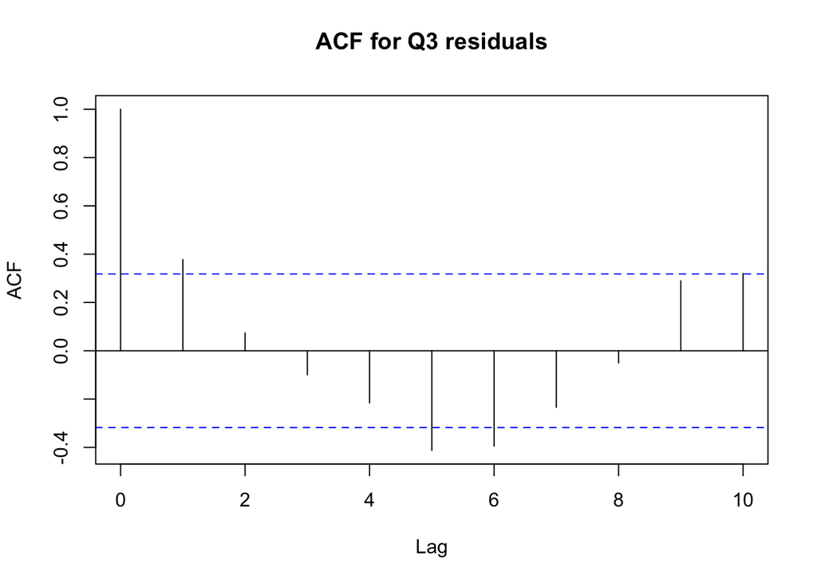

```r
## plot ACF of innovations
acf(t(innov), lag.max=10, main="ACF for Q3 residuals")
```

There is some indication that our model is not adequately accounting for autocorrelation in the residuals (i.e., signficant correlation at lag=1).

# Question 4

Fit the model specified by Equation 16 with the winter PDO index as the covariate (`PDO.t3`). What is the mean level of productivity? Plot the ts of $\delta_t$ and note the AICc for this model. Also plot appropriate model diagnostics.

Again we need to fit a DLM so that $\alpha$ and $\beta$ are time-invariant, but $\delta$ varies by year. As for Q3, $\mathbf{Q}$ should be

$$\begin{equation}
\mathbf{Q} = \begin{bmatrix}
0&0&0 \\
0&0&0 \\
0&0&q_\delta \end{bmatrix}
\end{equation}$$

```r
## number of regr coefs
m <- 3
## MARSS model defn
## for process eqn
B <- diag(m) ## 2x2; Identity
U <- matrix(0,nrow=m,ncol=1)
Q <- matrix(list(0),m,m)
## place delta last--it's the only one to time-vary
Q[3,3]=("q_delta")
## for observation eqn
Z <- array(NA, c(1,m,TT)) ## NxMxT; empty for now
Z[1,1,] <- rep(1,TT)  ## 1's for intercept
Z[1,2,] <- SRdata[,2] ## Sp regr variable
Z[1,3,] <- SRdata[,5] ## winter PDO regr variable
A <- matrix(0) ## 1x1; scalar = 0
R <- matrix("r") ## 1x1; scalar = r
## only need starting values for regr parameters
inits_list <- list(x0=matrix(c(0,0,0), nrow=m))
## list of model matrices & vectors
mod_list <- list(B=B, U=U, Q=Q, Z=Z, A=A, R=R)
## list of control params
con_list <- list(maxit=2000, allow.degen=TRUE)
## fit DLM
Q4 <- MARSS(dat, inits=inits_list, model=mod_list, control=con_list)
```

```
## Success! abstol and log-log tests passed at 777 iterations.
## Alert: conv.test.slope.tol is 0.5.
## Test with smaller values (<0.1) to ensure convergence.
## Alert: Numerical warnings were generated. Print the $errors element of output to see the warnings.
##
## MARSS fit is
## Estimation method: kem
## Convergence test: conv.test.slope.tol = 0.5, abstol = 0.001
## Estimation converged in 777 iterations.
## Log-likelihood: -34.09679
## AIC: 78.19358   AICc: 80.06858
##
##            Estimate
## R.r        7.18e-01
## Q.q_delta  0.00e+00
## x0.X1      7.50e-01
## x0.X2     -2.03e-05
## x0.X3      6.45e-02
##
## Standard errors have not been calculated.
## Use MARSSparamCIs to compute CIs and bias estimates.
##
## MARSSkem warnings. Type MARSSinfo() for help.
##  MARSSkem: The soln became unstable and logLik DROPPED.
##
## Use control$trace=1 to generate a more detailed error report.
```

```r
## mean productivity
mean(Q4$states[1,])
```

```
## [1] 0.74952
```

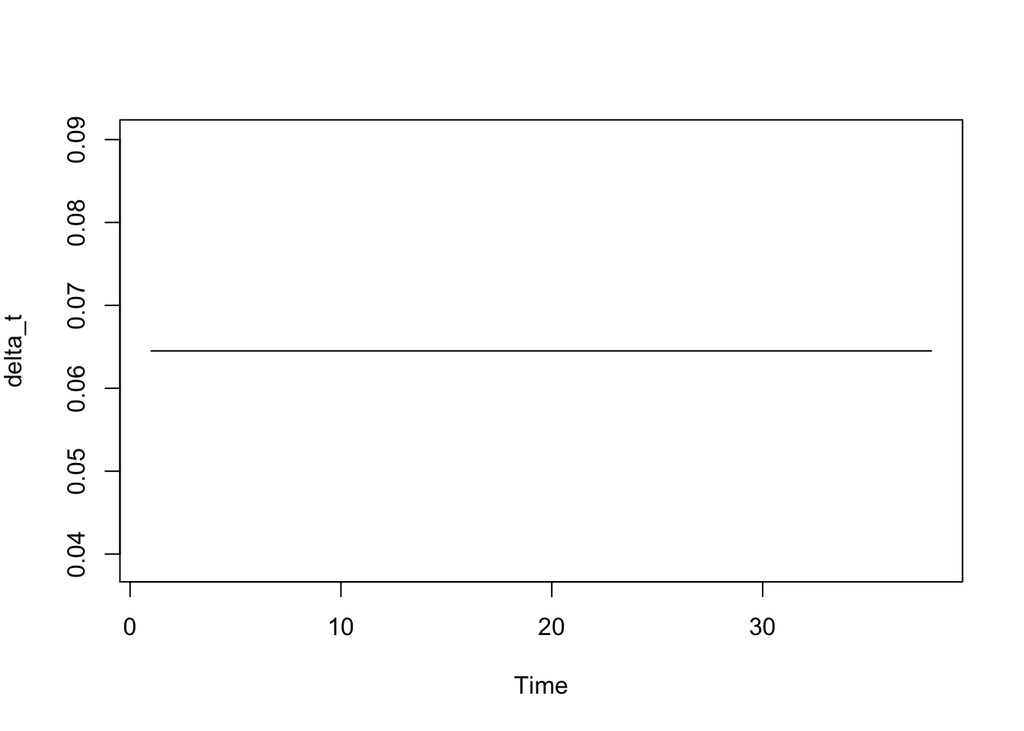

```r
## plot the time-varying effect of PDO
plot.ts(Q4$states[3,], ylab=expression(delta_t))
```

Again, it appears as though there is no data support for a time-varying effect of PDO.

```r
## get AIC
Q4$AICc
```

```
## [1] 80.06858
```

Here are some diagnostic plots:

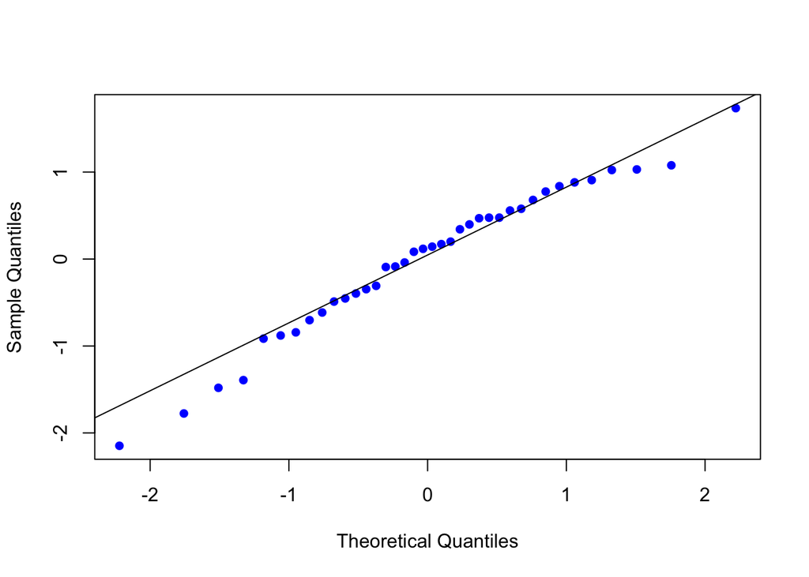

```r
## get list of Kalman filter output
kf_out <- MARSS::MARSSkfss(Q4)
## forecast errors
innov <- kf_out$Innov
## Q-Q plot of forecast errors
qqnorm(t(innov), main="", pch=16, col="blue")
## add y=x line for easier interpretation
qqline(t(innov))
```

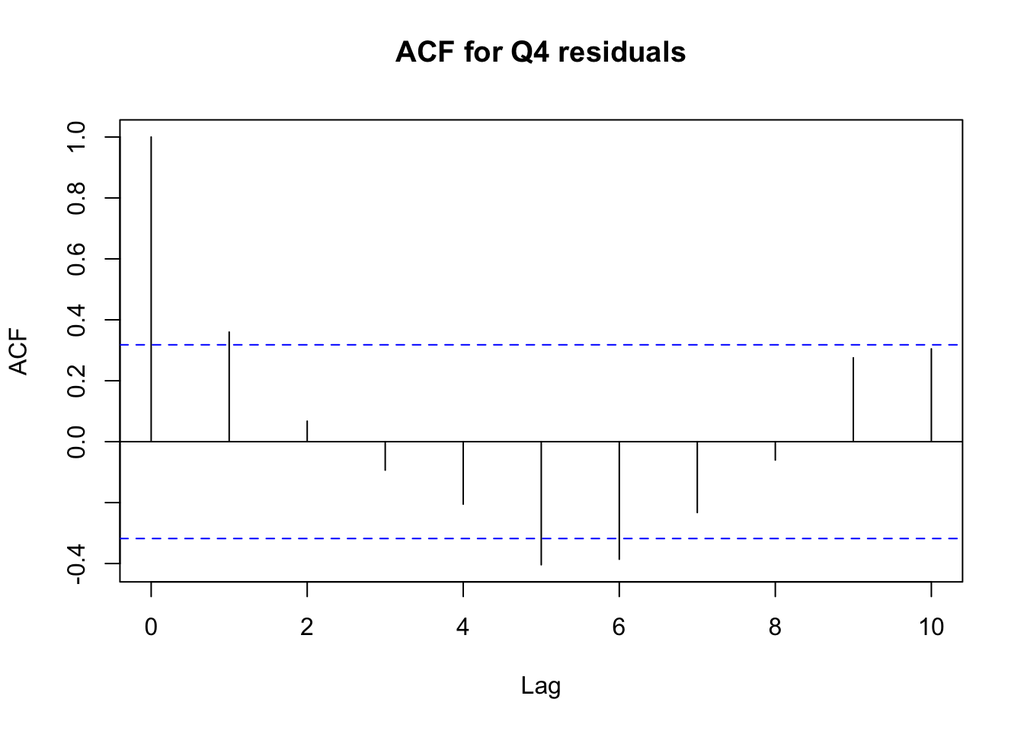

```r
## plot ACF of innovations
acf(t(innov), lag.max=10, main="ACF for Q4 residuals")
```

# Question 5

Based on AICc, which of the models above is the most parsimonius? Is it well behaved ($i.e.$, are the model assumptions met)? Plot the model forecasts for the best model. Is this a good forecast model?

Here is a table of AICc values for all 4 models.

```r
tbl_aicc <- data.frame(model=paste0("Q",seq(4)),
                       AICc=round(c(Q1$AICc,Q2$AICc,Q3$AICc,Q4$AICc),1))
tbl_aicc
```

```
##   model  AICc
## 1    Q1 104.1
## 2    Q2 106.4
## 3    Q3  80.5
## 4    Q4  80.1
```

```r
## get list of Kalman filter output
kf_out <- MARSS::MARSSkfss(Q1)
## forecasts of regr parameters; 2xT matrix
eta <- kf_out$xtt1
## predictor variable (1's only for the intercept)
Z <- array(1, c(1,1,TT))   ## NxMxT; empty for now
## ts of E(forecasts)
fore_mean <- vector()
for(t in 1:TT) {
  fore_mean[t] <- Z[,,t] %*% eta[,t,drop=F]
}
## variance of regr parameters; 1x2xT array
Phi <- kf_out$Vtt1
## obs variance; 1x1 matrix
R_est <- coef(Q1, type="matrix")$R
## ts of Var(forecasts)
fore_var <- vector()
for(t in 1:TT) {
  tZ <- matrix(Z[,,t],1,1) ## transpose of Z
  fore_var[t] <- Z[,,t] %*% Phi[,,t] %*% tZ + R_est
}
```

And now we can plot them.

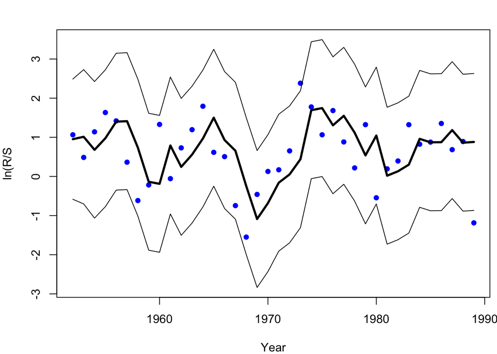

```r
fup <- fore_mean+2*sqrt(fore_var)
flo <- fore_mean-2*sqrt(fore_var)
par(mar=c(4,4,0.1,0), oma=c(0,0,2,0.5))
ylims=c(min(flo),max(fup))
plot(SRdata$brood.yr, t(dat), type="p", pch=16, ylim=ylims,
     col="blue", xlab="Year", ylab="ln(R/S") ##, xaxt="n")
lines(SRdata$brood.yr, fore_mean, type="l", xaxt="n", ylab="", lwd=3)
lines(SRdata$brood.yr, fup)
lines(SRdata$brood.yr, flo)
```

Overall, the accuracy of the forecasts is a bit suspect as many observations are at 0.5+ log-units from the forecast. Although most of the observed ln(R/S) fell within the 95% forecast intervals, the intervals themselves are relatively large and span a large range of R/S.